# STAT 240 Discussion 8

## Questions

### 1

For each scenario, explain why the random variable does *not* have a binomial distribution.

1. A bucket contains 10 colored tokens with five that are red and five that are blue. Four tokens are drawn at random from the bucket one at a time, but without replacing the tokens drawn. $X_1$ is the number of red tokens selected.
2. A fair coin is tossed repeatedly until the tenth head is tossed. $X_2$ is the number of tails tossed prior to the tenth head.
3. Four buckets each contain a total of five tokens each, some red and some blue. The number of red tokens in the buckets are 1, 2, 3, and 4 with blue tokens making up the remainder. One token is drawn at random from each bucket. $X_3$ is the total number of red tokens drawn.

### 2

Let $X \sim \operatorname{Binomial}(25,0.4)$.

#### A

Calculate and report the mean $\mu=\mathrm{E}(X)$ and the standad deviation $\sigma=\sqrt{\operatorname{Var}(X)}$

#### B

Calculate $\text{P}(X \geq 14)$

#### C

Create a graph of the $\operatorname{Binomial}(25,0.4)$ distribution. Color the segments for $x=14,15,...,25$ red and use gray for the rest. Plot using `theme_minimal()`.

You may edit the code in this block which does something similar for a different problem. Note the use of `geom_binom_density()` with different values of `a` AND `b`.

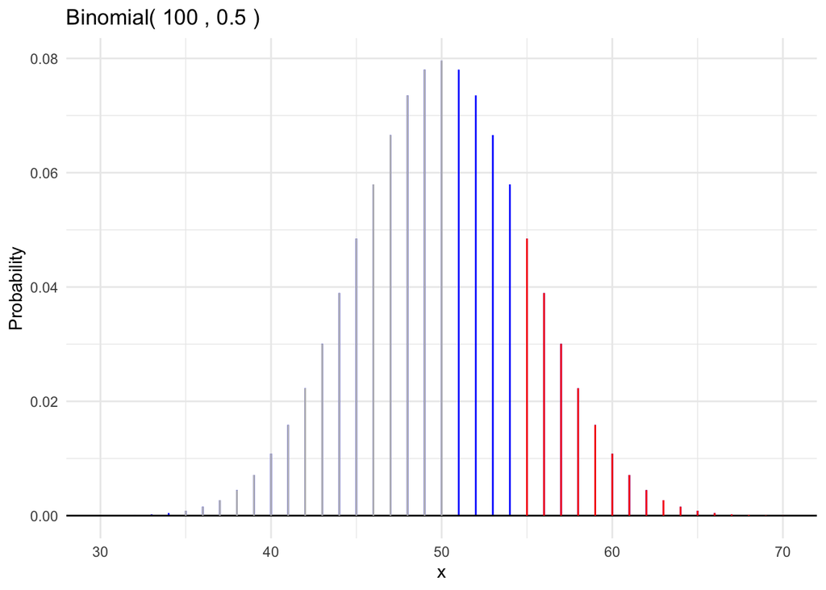

```r
gbinom(100, 0.5, a = 30, b = 70) +
  geom_binom_density(100, 0.5, a = 35, b = 50, color = "gray") +
  geom_binom_density(100, 0.5, a = 55, b = 70, color = "red") +
  theme_minimal()
```

### 3

Create a data frame with columns `n`, `p`, `x`, `mu`, and `prob` where:

- `n` varies from 2 to 100 by twos (so each `n` value is even);
- `p` equals 0.5;
- `x` is $n/2$;
- `mu` is the mean of the distribution;
- `prob` is $P(X = x)$

Show the first few rows using `head()`.

**(a)** What is the relationship between `x` and `mu`?

**(b)** Make a line graph of `prob` versus `n`.

**(c)** Describe the pattern: how does the probability that a random variable is equal to the mean (when the mean is a possible value) change as $n$ increases?

### 4

The central limit theorem implies that the binomial distribution converges to a normal distribution as $n$ increases. This problem will examine one aspect of the convergence, namely the right tail probability of being more than two standard deviations above the mean, $P(X > \mu + 2\sigma)$.

**(a)** What is the probability that a normal random variable with mean $\mu$ and standard deviation $\sigma$ exceeds $\mu + 2 \sigma$? Display answer rounded to four decimal places.

**(b)**

Create a data frame with columns `n`, `p`, `mu`, `sigma`, `x`, and `prob` where:  
- `n` varies from 1 to 1000 by ones;  
- `p` equals 0.5;  
- `mu` is the mean of the distribution;  
- `sigma` is the standard deviation of the distribution;  
- `x` equals `mu` + 2*`sigma`;  
- `prob` is $P(X > x)$

Display the first few rows of the data frame with `head()`.

**(c)** Plot the right tail probabilities versus $n$. Add a red, dashed, horizontal line at the value you found in part **(a)**. Add a smooth curve which lessens the visual impact of the oscillations due to the discreteness of the binomial distribution.

**(d)** Repeat parts **(b)** and **(c)** if $p = 0.005$.

**(e)**

Ignoring the oscillations, how do the patterns of the two smooth curves in the graphs differ from one another, especially when $n$ is large?

### 5

Repeat problems 4B and 4C if $p=0.005$

### 6

Draw graphs of the binomial distributions for $n=500$ and $p = 0.5$ and $p = 0.005$, scaled so that the x axis is restricted to where the probabilities are relatively large. (One graph for each of the two $p$’s.) Overlay each plot with a red normal density with a mean and standard deviation that matches the mean and standard deviation of the corresponding binomial distribution. (Use functions in *gprob.R* for these graphs and set `scale=TRUE`.)